# **VIH y la SOCIEDAD**

Rocío Águeda

2022-12-12

## Introducción

El VIH (virus de la inmunodeficiencia humana) es un virus que ataca el sistema inmunitario del cuerpo, se transmite a través de la sangre y actualmente no tiene cura, únicamente se puede controlar con una adecuada atención médica.

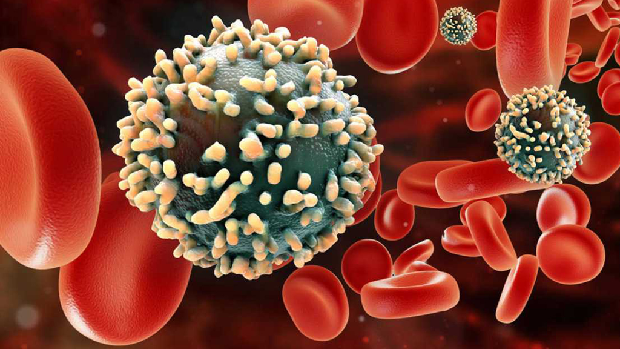

Imagen VIH.

### *Objetivos*

- Investigar si existe relación entre el contagio del virus y el ambiente social.

## Métodos

### *Carga de paquetes*

Para llevar a cabo la investigación se ha hecho uso de algunos paquetes necesarios para leer, modificar, unir y plasmar los datos de forma visual a modo de tablas y gráficos.

```r
library(readr)
library(dplyr)
library(ggplot2)
library(tidyverse)
library(DT)
```

### *Carga de datos*

Los datos que he utilizado estaban contenidos en 2 tablas, “Registro_regional_de_sida” y “Registro_nuevas_infecciones_por_vih”. Los obtuve a travésde la sección de datos abiertos de la página de la [Junta de Castilla y León](https://datosabiertos.jcyl.es/web/es/datos-abiertos-castilla-leon.html). Ambas han sido descargadas en formato CSV.

#### registro_regional_de_sida

Esta tabla contiene el Sexo, Provincia, País, Edad, Código, Grupo de riesgo y Año de diagnóstico del VIH a personas que residen en alguna de las provincias de Castilla y León entre 1982 y 2009.

```r
registro_regional_de_sida <- read_delim("INPUT/DATA/registro-regional-de-sida.csv",
                                  delim = ";", escape_double = FALSE, trim_ws = TRUE)

datatable(registro_regional_de_sida)
```

|  | Año de diagnóstico | Sexo | Edad años | Edad meses | provincia | País de origen | Código Grupo de riesgo | Grupo de riesgo |
| --- | --- | --- | --- | --- | --- | --- | --- | --- |
| 1 | 1985 | H | 28 | 0 | Salamanca | España | 20 | Personas que se inyectan drogas |
| 2 | 1982 | M | 28 | 0 | Valladolid | España | 20 | Personas que se inyectan drogas |
| 3 | 1987 | H | 10 | 0 | Palencia | España | 40 | Receptores de hemoderivados |
| 4 | 1987 | H | 30 | 0 | Salamanca | España | 20 | Personas que se inyectan drogas |
| 5 | 1987 | M | 25 | 0 | Burgos | España | 77 | Relaciones Heterosexuales |
| 6 | 1987 | H | 62 | 0 | León | España | 41 | Receptores de hemoderivados |
| 7 | 1987 | M | 32 | 0 | Valladolid | España | 20 | Personas que se inyectan drogas |
| 8 | 1987 | H | 52 | 0 | Salamanca | España | 20 | Personas que se inyectan drogas |
| 9 | 1987 | H | 35 | 0 | Valladolid | España | 10 | Varones homosexuales / bisexuales |
| 10 | 1986 | M | 3 | 0 | Valladolid | España | 64 | Hijo de madre a riesgo |

[output cut: 2692 more lines]

#### registro_nuevas_infecciones_por_vih

Se esta otra tabla obtenemos unos datos bastante similares a los anteriores, Sexo, Provincia, País, Edad, Código y Grupo de riesgo y Año de diagnóstico entre otros, del VIH a personas que habitan en cualquiera de las provincias de Castilla y León entre 2009 y 2021.

```r
registro_nuevas_infecciones_por_vih <- read_delim("INPUT/DATA/registro-nuevas-infecciones-por-vih.csv",col_types = cols(
                                        Año = readr::col_integer(),
                                        "VIH" = readr::col_integer()),
                                        delim = ";", escape_double = FALSE, trim_ws = TRUE)

datatable(registro_nuevas_infecciones_por_vih)
```

|  | Provincia residencia | País de nacimiento (si no es España) | Edad | Sexo | VIH | Código Grupo de riesgo asignado | grupo riesgo | Estado clínico de la infección por VIH | Test positivo confirmado frente a | Conducta sexual |
| --- | --- | --- | --- | --- | --- | --- | --- | --- | --- | --- |
| 1 | LEON | ESPAÑA | 18 | H | 2009 | 80 | Grupo de riesgo desconocido | PrimoInf | VIH1 | Desconocido |
| 2 | SORIA | ESPAÑA | 44 | H | 2009 | 70 | Relaciones Heterosexuales | PrimoInf | VIH1 | Heterosex |
| 3 | BURGOS | ESPAÑA | 39 | M | 2009 | 77 | Relaciones Heterosexuales | Asintom | VIH1 | Heterosex |
| 4 | SORIA | ESPAÑA | 43 | H | 2009 | 10 | Varones homosexuales / bisexuales | PrimoInf | VIH1 | Homosex |
| 5 | AVILA | RUMANA | 38 | M | 2009 | 70 | Relaciones Heterosexuales | SIDA | VIH1 | Heterosex |
| 6 | SALAMANCA | ESPAÑA | 40 | H | 2009 | 20 | Personas que se inyectan drogas | SIDA | VIH1 | Heterosex |
| 7 | SEGOVIA | REPUBLICA DOMINICANA | 37 | H | 2010 | 10 | Varones homosexuales / bisexuales | Asintom | VIH2 | Homosex |
| 8 | VALLADOLID | ESPAÑA | 47 | H | 2009 | 20 | Personas que se inyectan drogas | SIDA | VIH1 | Desconocido |
| 9 | VALLADOLID | CAMERUN | 45 | M | 2009 | 75 | Relaciones Heterosexuales | SIDA | VIH1 | Heterosex |
| 10 | VALLADOLID | ESPAÑA | 43 | H | 2009 | 80 | Grupo de riesgo desconocido | Asintom | VIH1 | Desconocido |

[output cut: 1425 more lines]

### *Exploración de los datos*

Una vez cargadas, pasamos a transformar las tablas originales cambiando los nombres de las columnas por otros más correctos semánticamente, recolocamos, seleccionamos y filtramos los datos que sean de nuestro interés.

```r
registroRegionalSida <- rename(.data = registro_regional_de_sida, Año = "Año de diagnóstico", Edad = "Edad años", Codigo_Riesgo = "Código Grupo de riesgo", Grupo_Riesgo = "Grupo de riesgo", Provincia = "provincia")%>%
  relocate(., "Edad meses", .after = Grupo_Riesgo)%>%
  relocate(.,"País de origen", .after = Grupo_Riesgo)%>%
  dplyr::filter(Año < 2009)%>%
  select(., Año:Grupo_Riesgo)%>%
  mutate(Provincia = factor(Provincia, levels = c("Burgos", "León", "Avila", "Zamora", "Salamanca", "Segovia", "Valladolid", "Palencia", "Soria"), labels = c("BURGOS", "LEON", "AVILA", "ZAMORA", "SALAMANCA", "SEGOVIA", "VALLADOLID", "PALENCIA", "SORIA")))


datatable(registroRegionalSida)
```

|  | Año | Sexo | Edad | Provincia | Codigo_Riesgo | Grupo_Riesgo |
| --- | --- | --- | --- | --- | --- | --- |
| 1 | 1985 | H | 28 | SALAMANCA | 20 | Personas que se inyectan drogas |
| 2 | 1982 | M | 28 | VALLADOLID | 20 | Personas que se inyectan drogas |
| 3 | 1987 | H | 10 | PALENCIA | 40 | Receptores de hemoderivados |
| 4 | 1987 | H | 30 | SALAMANCA | 20 | Personas que se inyectan drogas |
| 5 | 1987 | M | 25 | BURGOS | 77 | Relaciones Heterosexuales |
| 6 | 1987 | H | 62 | LEON | 41 | Receptores de hemoderivados |
| 7 | 1987 | M | 32 | VALLADOLID | 20 | Personas que se inyectan drogas |
| 8 | 1987 | H | 52 | SALAMANCA | 20 | Personas que se inyectan drogas |
| 9 | 1987 | H | 35 | VALLADOLID | 10 | Varones homosexuales / bisexuales |
| 10 | 1986 | M | 3 | VALLADOLID | 64 | Hijo de madre a riesgo |

[output cut: 2346 more lines]

```r
registroNuevasInfecciones <- rename(.data = registro_nuevas_infecciones_por_vih, Provincia = "Provincia residencia", Codigo_Riesgo = "Código Grupo de riesgo asignado", Grupo_Riesgo = "grupo riesgo", Año = "VIH")%>%
  relocate(., "País de nacimiento (si no es España)", .before = "Estado clínico de la infección por VIH")%>%
  select(., Provincia:Grupo_Riesgo)%>%
  mutate(Grupo_Riesgo = factor(Grupo_Riesgo, levels = c("Grupo de riesgo desconocido", "Hijo de madre a riesgo", "Personas que se inyectan drogas", "Personas que se inyectan drogas / Varones homo/bisexuales", "Receptores de hemoderivados", "Receptor trasfusiones", "Relaciones Heterosexuales", "Varones homosexuales / bisexuales"), labels = c("Grupo de riesgo desconocido", "Hijo de madre a riesgo", "Personas que se inyectan drogas", "Personas que se inyectan drogas / Varones homo/bisexuales", "Receptores de hemoderivados", "Receptores de transfusión", "Relaciones Heterosexuales", "Varones homosexuales / bisexuales")))

datatable(registroNuevasInfecciones)
```

|  | Provincia | Edad | Sexo | Año | Codigo_Riesgo | Grupo_Riesgo |
| --- | --- | --- | --- | --- | --- | --- |
| 1 | LEON | 18 | H | 2009 | 80 | Grupo de riesgo desconocido |
| 2 | SORIA | 44 | H | 2009 | 70 | Relaciones Heterosexuales |
| 3 | BURGOS | 39 | M | 2009 | 77 | Relaciones Heterosexuales |
| 4 | SORIA | 43 | H | 2009 | 10 | Varones homosexuales / bisexuales |
| 5 | AVILA | 38 | M | 2009 | 70 | Relaciones Heterosexuales |
| 6 | SALAMANCA | 40 | H | 2009 | 20 | Personas que se inyectan drogas |
| 7 | SEGOVIA | 37 | H | 2010 | 10 | Varones homosexuales / bisexuales |
| 8 | VALLADOLID | 47 | H | 2009 | 20 | Personas que se inyectan drogas |
| 9 | VALLADOLID | 45 | M | 2009 | 75 | Relaciones Heterosexuales |
| 10 | VALLADOLID | 43 | H | 2009 | 80 | Grupo de riesgo desconocido |

[output cut: 1425 more lines]

Tras explorar los datos y ver que se pueden unir las tablas sin generar ningun tipo de conflicto procedemos a ello.

```r
union <- full_join(x = registroRegionalSida, y = registroNuevasInfecciones)
```

[output not shown]

```r
datatable(union)
```

|  | Año | Sexo | Edad | Provincia | Codigo_Riesgo | Grupo_Riesgo |
| --- | --- | --- | --- | --- | --- | --- |
| 1 | 1985 | H | 28 | SALAMANCA | 20 | Personas que se inyectan drogas |
| 2 | 1982 | M | 28 | VALLADOLID | 20 | Personas que se inyectan drogas |
| 3 | 1987 | H | 10 | PALENCIA | 40 | Receptores de hemoderivados |
| 4 | 1987 | H | 30 | SALAMANCA | 20 | Personas que se inyectan drogas |
| 5 | 1987 | M | 25 | BURGOS | 77 | Relaciones Heterosexuales |
| 6 | 1987 | H | 62 | LEON | 41 | Receptores de hemoderivados |
| 7 | 1987 | M | 32 | VALLADOLID | 20 | Personas que se inyectan drogas |
| 8 | 1987 | H | 52 | SALAMANCA | 20 | Personas que se inyectan drogas |
| 9 | 1987 | H | 35 | VALLADOLID | 10 | Varones homosexuales / bisexuales |
| 10 | 1986 | M | 3 | VALLADOLID | 64 | Hijo de madre a riesgo |

[output cut: 3781 more lines]

## Gráficos

A partir de la información contenida en estas tablas podemos representarla gráficamente para ver las posibles relaciones.

En pirmer lugar graficaremos la relación (si es que existe), entre el número de casos por provincia y grupo de riesgo durante los años comprendidos entre el 82 y el 2009.

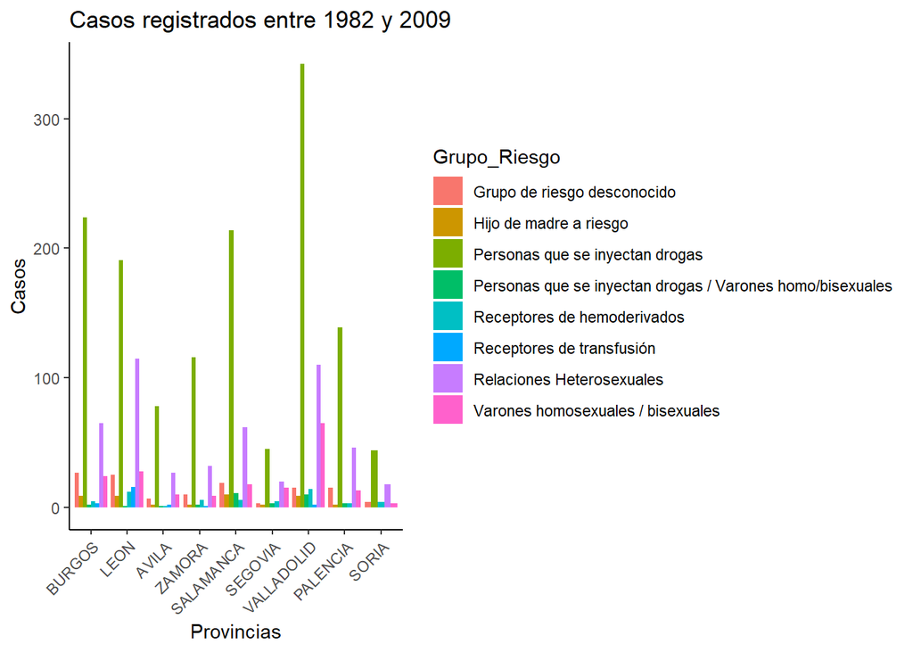

```r
casosAntiguos <- ggplot(data = registroRegionalSida, aes(x = Provincia)) +
  geom_bar(aes(fill = Grupo_Riesgo), position = "dodge")+
  theme_classic()+
  theme(axis.text.x = element_text(angle = 45, hjust = 1))+
  labs(x = "Provincias", y = "Casos", title = "Casos registrados entre 1982 y 2009", colour = "Grupo de Riesgo" )

print(casosAntiguos)
```

```r
#jpeg("casosAntiguos.jpeg", quality = 75)
#plot(rnorm(20))
#dev.off()
```

A continuación, graficaremos la relación (si es que existe), entre el número de casos por provincia y grupo de riesgo durante los años comprendidos entre el 2009 y el 2021.

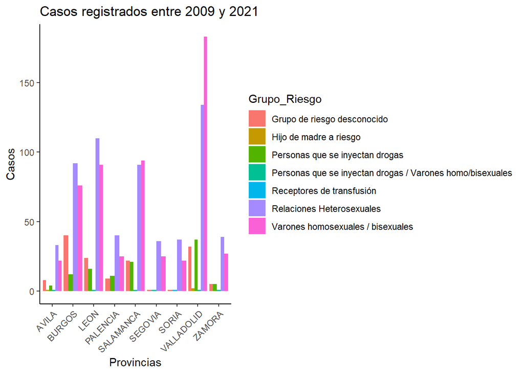

```r
casosNuevos <- ggplot(data = registroNuevasInfecciones, aes(x = Provincia)) +
  geom_bar(aes(fill = Grupo_Riesgo), position = "dodge")+
  theme_classic()+
  theme(axis.text.x = element_text(angle = 45, hjust = 1))+
  labs(x = "Provincias", y = "Casos", title = "Casos registrados entre 2009 y 2021", colour = "Grupo de Riesgo" )

print(casosNuevos)
```

```r
#jpeg("casosNuevos.jpeg", quality = 75)
#plot(rnorm(20))
#dev.off()
```

En la siguiente figura intentaremos comprobar si existe relación entre la edad por sexo y año de diagnóstico de los afectados. Y así comprobar si estas infieren en la trnasmisión del virus.

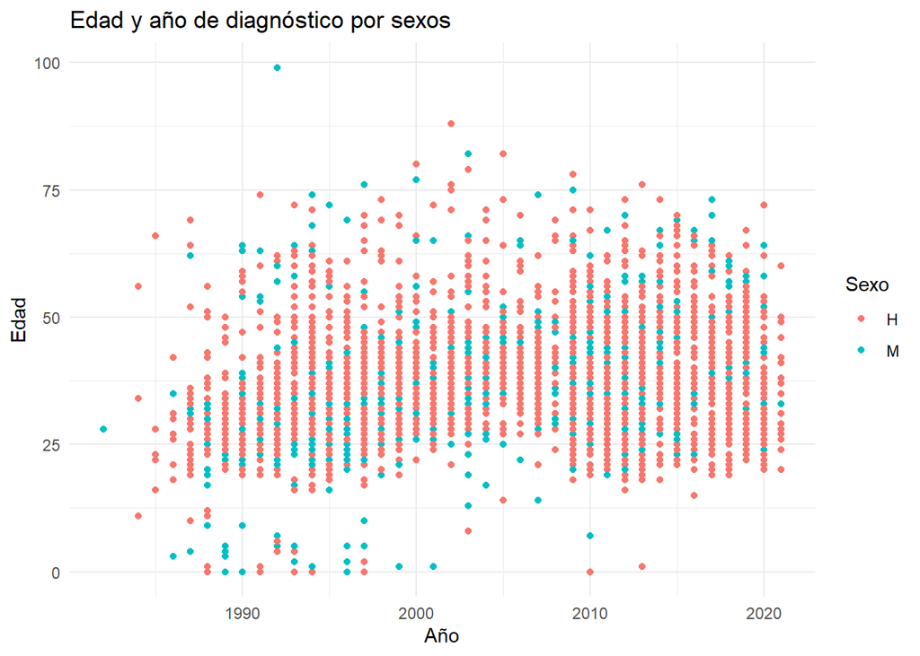

```r
edadesPorAñoSexo <- ggplot(data = union, aes(x = Año, y = Edad))+
 geom_point(aes(colour = factor(Sexo)))+
  theme_minimal()+
  labs(x = "Año", y = "Edad", title = "Edad y año de diagnóstico por sexos", colour = "Sexo" )

print(edadesPorAñoSexo)
```

```r
#jpeg("edadesPorAñoSexo.jpeg", quality = 75)
#plot(rnorm(20))
#dev.off()
```

Visualizando el gráfico anterior podemos hacernos una idea de cual es la media de la edad por año pero no parece haber una relación. Para poder ver más claramente los datos, construimos otro parecido solo que esta vez será la media de edad de individuos registrados por año de cada sexo.

```r
unionpromediosEdad <- union%>%
  group_by(Año, Sexo)%>%
  summarise(across(c(Edad), ~ trunc(mean(.x, na.rm = TRUE))))
```

[output not shown]

```r
datatable(unionpromediosEdad)
```

|  | Año | Sexo | Edad |
| --- | --- | --- | --- |
| 1 | 1982 | M | 28 |
| 2 | 1984 | H | 33 |
| 3 | 1985 | H | 31 |
| 4 | 1986 | H | 28 |
| 5 | 1986 | M | 19 |
| 6 | 1987 | H | 31 |
| 7 | 1987 | M | 29 |
| 8 | 1988 | H | 29 |
| 9 | 1988 | M | 23 |
| 10 | 1989 | H | 30 |

[output cut: 65 more lines]

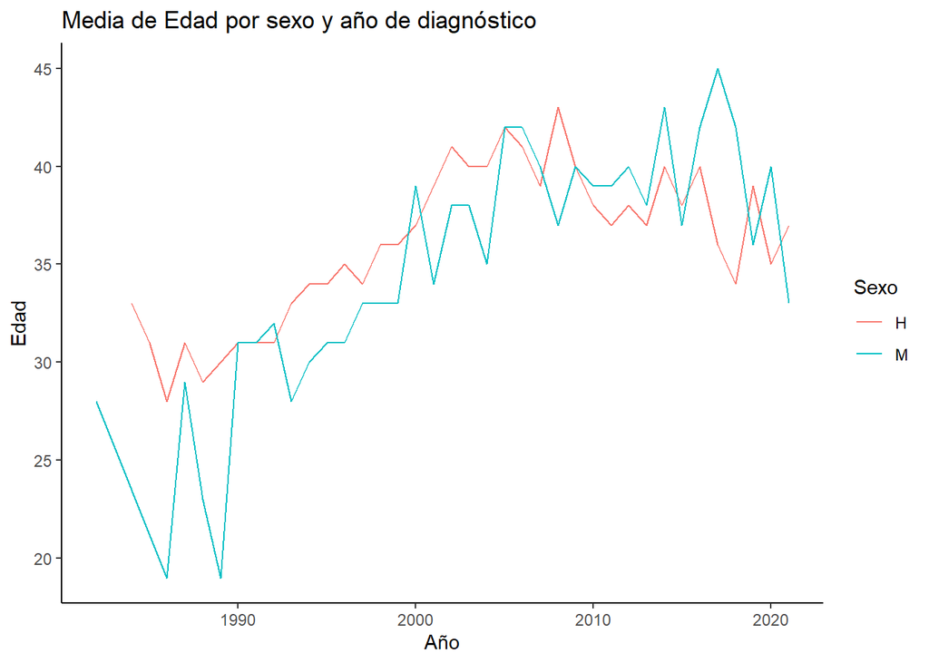

```r
promedioEdad <- ggplot(data = unionpromediosEdad, aes(x = Año, y = Edad, group = Sexo, color = Sexo))+
 geom_line()+
  theme_classic()+
  labs(x = "Año", y = "Edad", title = "Media de Edad por sexo y año de diagnóstico", colour = "Sexo" )

print(promedioEdad)
```

```r
#jpeg("promedioEdad.jpeg", quality = 75)
#plot(rnorm(20))
#dev.off()
```

A continuación hacemos el recuento de los sexos de los casos que tenemos registrados, quedando una clara constancia de que hay un mayor número de hombres con VIH que mujeres, pero esta relación nos pide que miremos la relación entre el grupo de riesgo y el sexo.

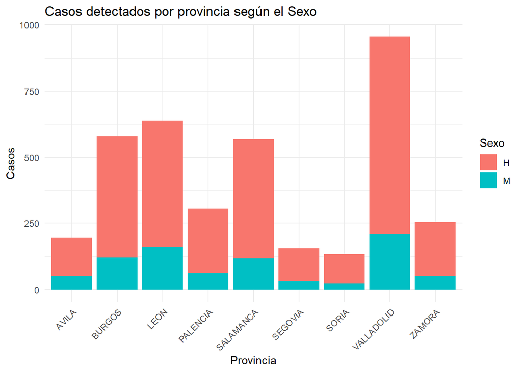

```r
numeroCasos <- ggplot(data = union, aes(x = Provincia))+
  geom_bar(aes(fill = Sexo))+
  theme_minimal()+
  theme(axis.text.x = element_text(angle = 45, hjust = 1))+
  labs(x = "Provincia", y = "Casos", title = "Casos detectados por provincia según el Sexo", colour = "Sexo" )

print(numeroCasos)
```

```r
#jpeg("numeroCasos.jpeg", quality = 75)
#plot(rnorm(20))
#dev.off()
```

En esta primera imagen observaremos la media de años de diagnóstico de los pacientes para cada sexo y grupo de riesgo.

```r
promedioAñosGrupoRiesgo <- union%>%
  group_by(Grupo_Riesgo, Sexo)%>%
  summarise(across(c(Año), ~ trunc(mean(.x, na.rm = TRUE))))
datatable(promedioAñosGrupoRiesgo)
```

|  | Grupo_Riesgo | Sexo | Año |
| --- | --- | --- | --- |
| 1 | Grupo de riesgo desconocido | H | 2007 |
| 2 | Grupo de riesgo desconocido | M | 2005 |
| 3 | Hijo de madre a riesgo | H | 1995 |
| 4 | Hijo de madre a riesgo | M | 1994 |
| 5 | Personas que se inyectan drogas | H | 1997 |
| 6 | Personas que se inyectan drogas | M | 1997 |
| 7 | Personas que se inyectan drogas / Varones homo/bisexuales | H | 1998 |
| 8 | Receptores de hemoderivados | H | 1990 |
| 9 | Receptores de hemoderivados | M | 1994 |
| 10 | Receptores de transfusión | H | 1991 |

[output cut: 5 more lines]

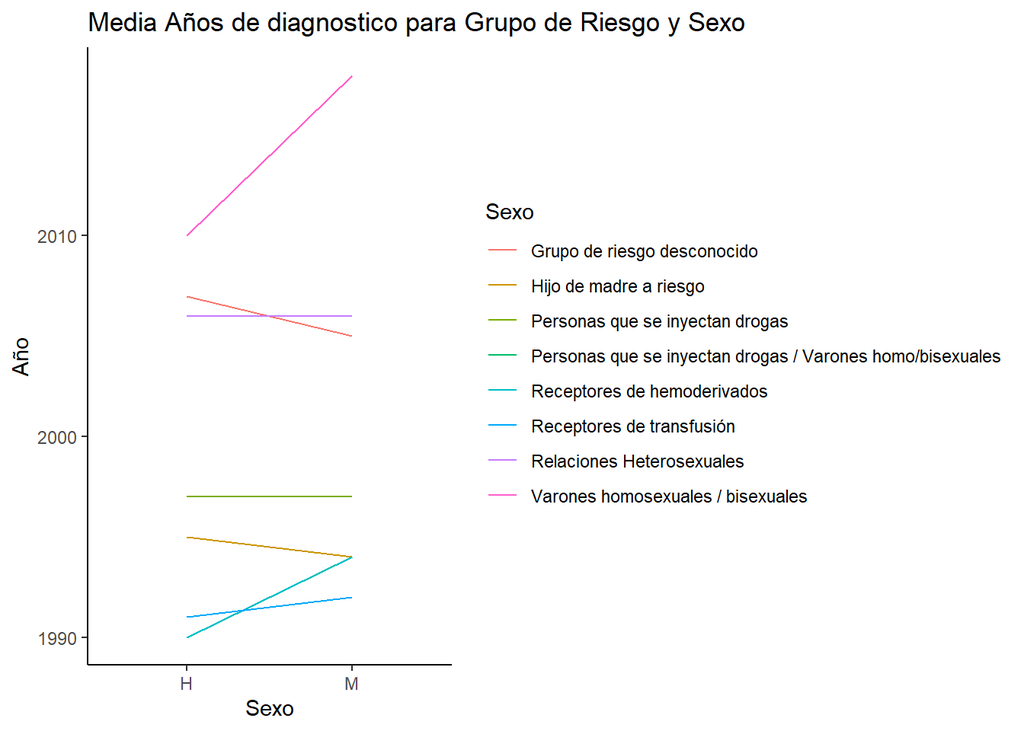

```r
promedioAños <- ggplot(data = promedioAñosGrupoRiesgo, aes(x = Sexo, y = Año, group = Grupo_Riesgo, color = Grupo_Riesgo))+
 geom_line()+
  theme_classic()+
  labs(x = "Sexo", y = "Año", title = "Media Años de diagnostico para Grupo de Riesgo y Sexo", colour = "Sexo" )

print(promedioAños)
```

```r
jpeg("promedioAños.jpeg", quality = 75)
plot(rnorm(20))
dev.off()
```

Como el gráfico anterior puede ser confuso y poco visual a pesar de que nos aporta algo de información, he pasado los datos a un gráfico de barras que cuenta los casos cada Grupo de Riesgo por Sexo.

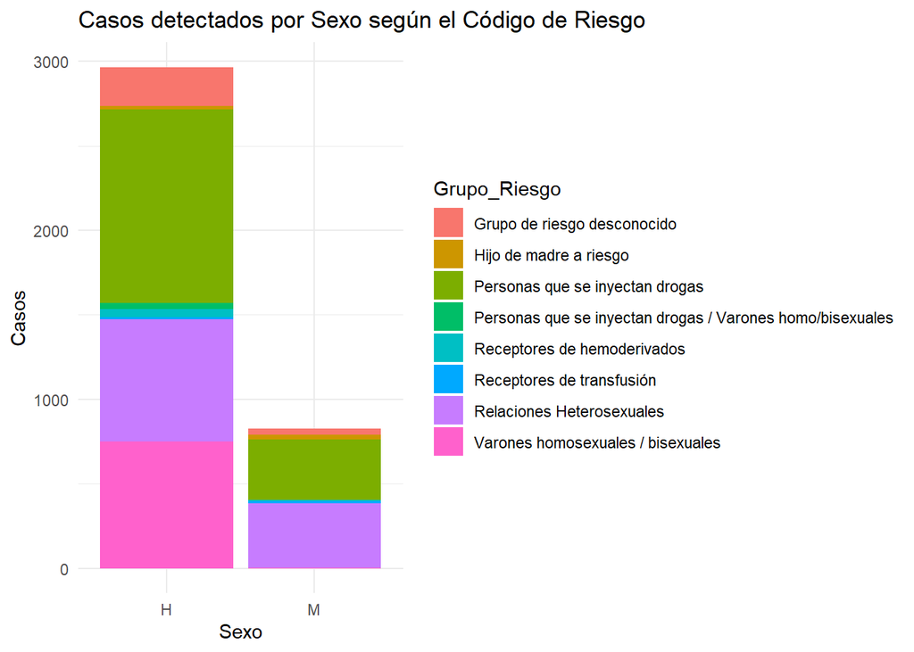

```r
casosCodigoRiesgo <- ggplot(data = union, aes(x = Sexo))+
  geom_bar(aes(fill = Grupo_Riesgo))+
  theme_minimal()+
  labs(x = "Sexo", y = "Casos", title = "Casos detectados por Sexo según el Código de Riesgo", colour = "Código de Riesgo" )

print(casosCodigoRiesgo)
```

```r
jpeg("casosCodigoRiesgo.jpeg", quality = 75)
plot(rnorm(20))
dev.off()
```

### *Conclusión*

En resumen, despúes de observar todos los datos, creo que existe una relación clara entre las causas de contagio de los pacientes registrados y el año en el que les fue diagnosticada la enfermedad.

Claramente hay que tener en cuenta que al ser una enfermedad con unos síntomas muy similares a los de una gripe o incluso nulos, hay muchas personas que pueden tener la enfermedad sin saberlo y arrastrarla y por lo tanto transmitirla. Además, los datos recogidos abarcan una comunidad autónoma de un país concreto, estando esta enfermedad presente en infinidad de lugares en el mundo.

## Referencias

https://ggplot2.tidyverse.org/reference/geom_bar.html

https://bookdown.org/yihui/rmarkdown/html-document.html

https://github.com/ajcanepa/PRACTICA_TEMA5